# Iceplant segmentation: initial model results on Corsica test imagery

First-pass deep-learning detection on BD ORTHO tiles, with validation & eradication context

Published

September 23, 2026

**In this document**

1. **Recap** — what these first-pass segmentation results are and are not.
2. **Model comparison — Corsica coastal tile** — the single-image “simple” model vs. the full Dangermond model, run on the same Corsica test tile.
3. **Multiple Locations** — applying model at additional locations
   - **Ile Rousse** — the Dangermond model over the Ile Rousse ferry-port headland.
   - **Mezu Mare** — the Dangermond model over the CBNC permanent monitoring plots on Mezu Mare, with ground-level photos of the plots.
4. **Validation sources** — where ground truth for these predictions could come from.
5. **Eradication efforts & local organisations** — active Corsica iceplant-removal programmes that double as potential validation partners.
6. **Next steps** — what to do before treating any of this as a map.

## Recap

Goal: test existing models with imagery from Corsica

- Applied the segmentation tutorial from Zhe to imagery in Corsica
- Examined two locations that have had iceplant infestations in the past.
- both images were taken in July

Other notes: - more research into potential ground truth data - various eradication efforts have taken place on the island, including in the one of the locations with test imagery - The test imagery is French **BD ORTHO** (IGN Geoplateforme, 0.2 m GSD, 4-band **RGB + NIR**, RGF93 / Lambert-93).

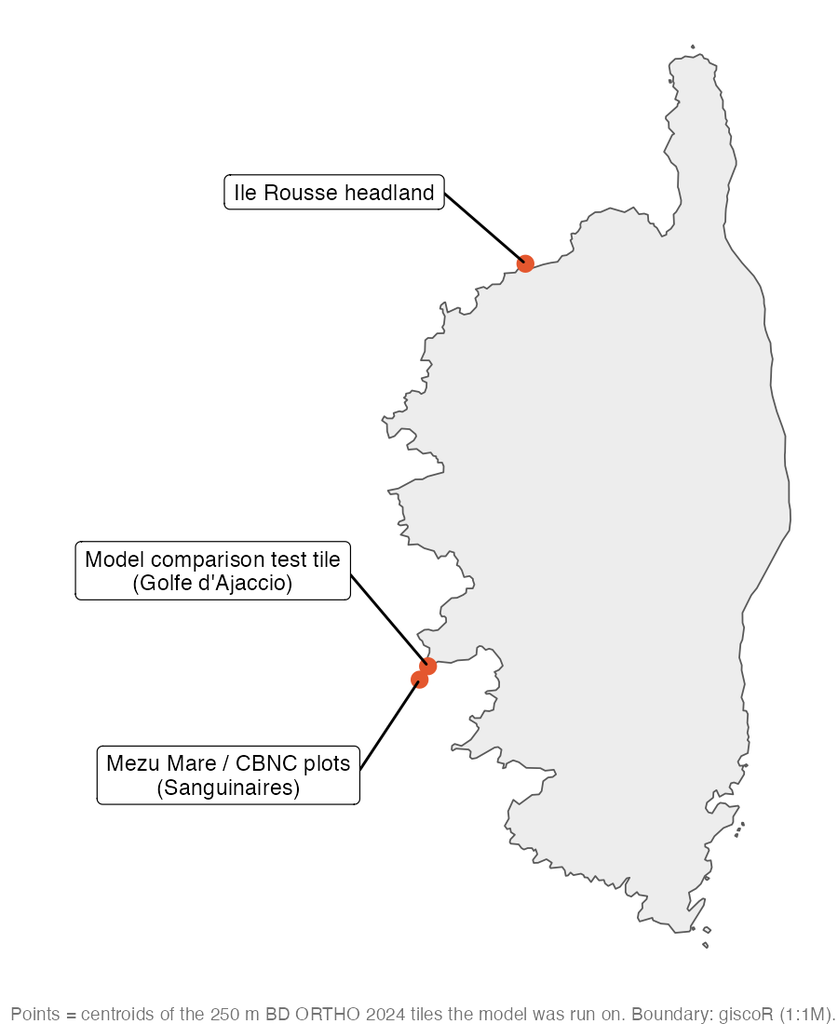

Figure 1: Where the model was run: the three Corsica BD ORTHO 2024 test tiles (250 m each), labelled with the report section that shows them. Built by `R/imagery/fig_corsica_sites.R` from the tiles’ own extents.

**These are qualitative, uncalibrated results.** No accuracy metrics, no threshold tuning, and no ground validation yet — the yellow outlines/fills are raw model output shown over the imagery. Read them as “does this look plausible?”, not as a finished map. See **Next steps**.

## Model comparison — Corsica coastal tile

Both models are run on the **same** Corsica coastal-headland tile so the only thing changing is the model. The models are:

- **Simple model** — trained on just the single NAIP test image from the segmentation tutorial. A minimal, one-image baseline: useful only as a floor to compare against.
- **Dangermond model** — the full, completed model used to map iceplant at the Dangermond Preserve, trained on NAIP plus 4-band imagery.

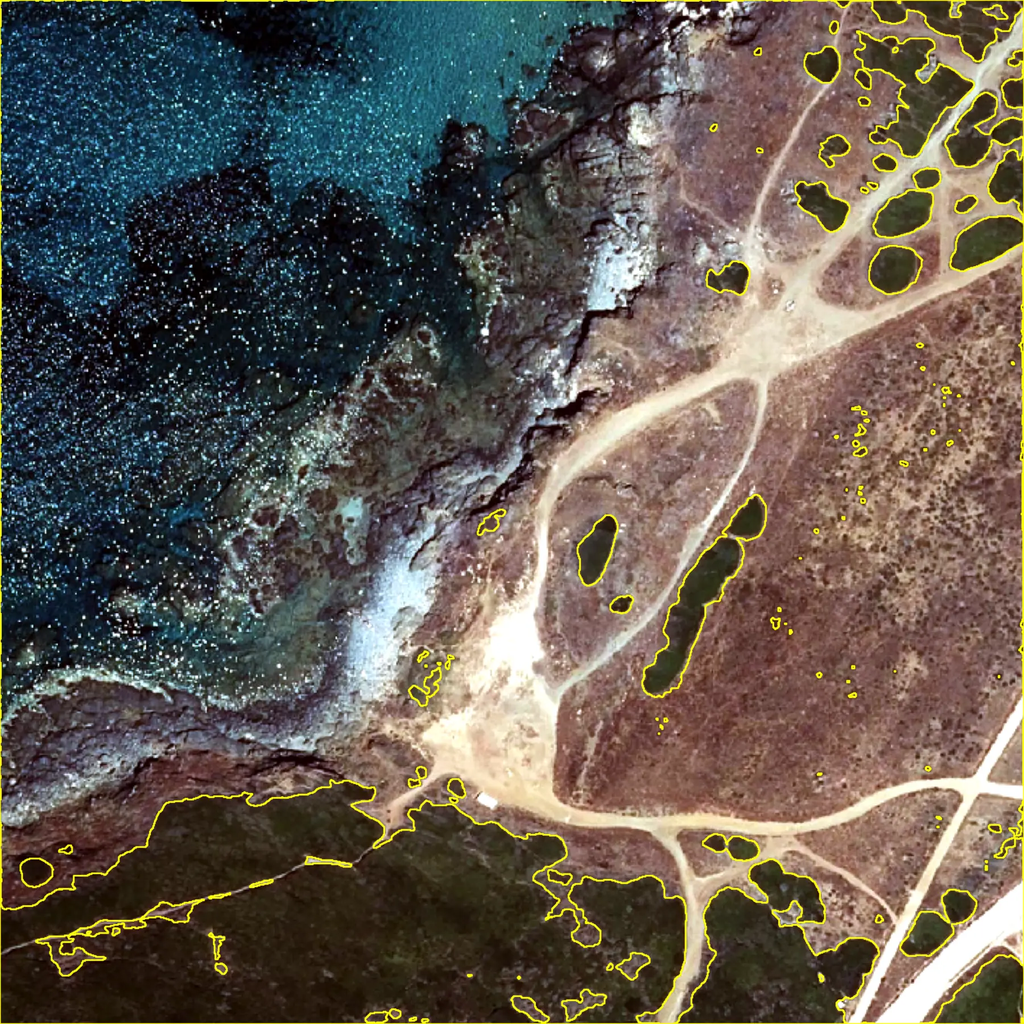

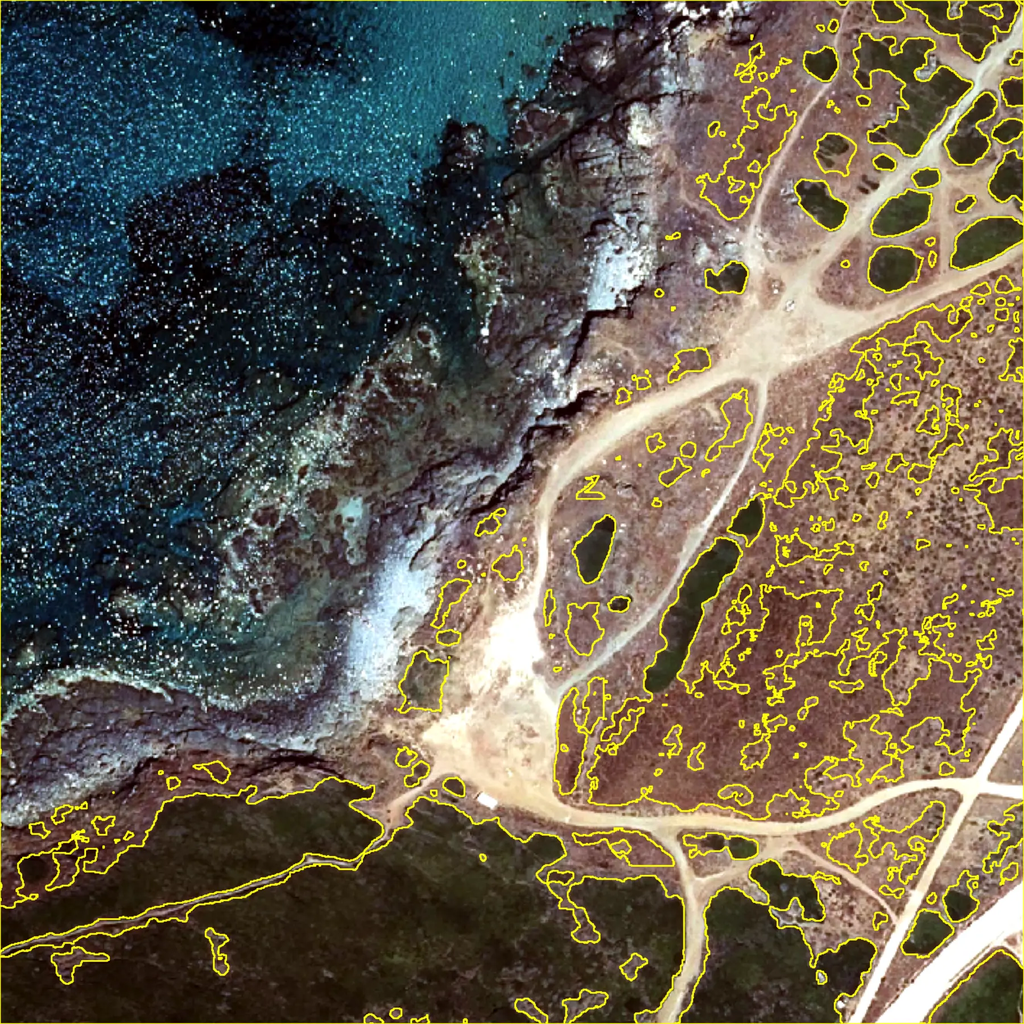

**Ground reference.** What that coastal iceplant actually looks like on the ground, at a Corsica headland like the one in the test tile:

[figure not shown]

Figure 4: Iceplant (*Carpobrotus*) mat blanketing a Corsica coastal headland — the ground-level view of the kind of continuous cover the models are trying to delineate from above. Source: Google Street View (contributor: eric BOTTARO, Aug 2020).

## Additional Locations

### Ile Rousse

The Dangermond model applied to a second Corsica site — the **Ile Rousse** ferry-port headland — at high resolution. This is a harder scene: buildings, car parks, roads, and bare rock sit right next to the iceplant.

There have been eradication efforts here, but streetview doesn’t have a lot of good imagery from when the aerial image was taken.

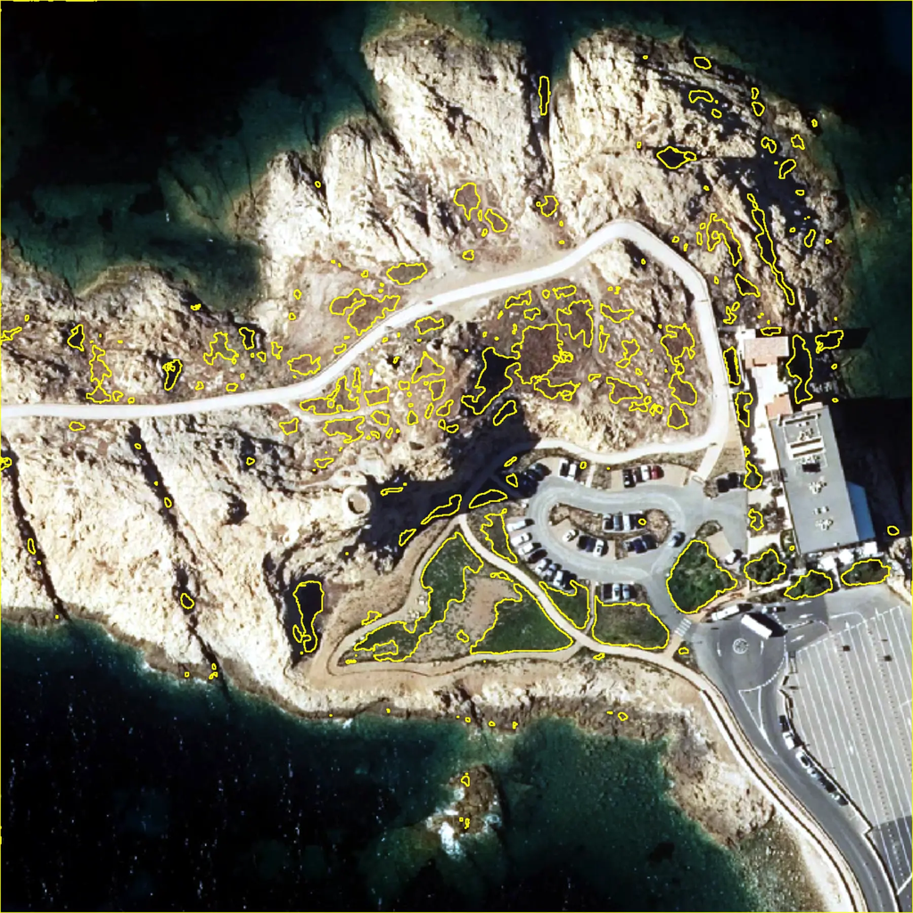

Figure 5: Dangermond model over the Ile Rousse headland (BD ORTHO, 0.2 m, 4-band). Yellow = predicted iceplant. The model concentrates detections on the vegetated ground between the port road and the shoreline and largely leaves buildings, tarmac, and the ferry terminal alone.

**Ground reference.** The same headland from the ground — iceplant in the foreground with the Ile Rousse ferry terminal behind:

[figure not shown]

Figure 6: Iceplant on the Ile Rousse headland, with the ferry terminal and Corsica Linea vessel behind — the ground view of the scene mapped above. Source: Google Street View.

### CBNC monitoring plots on Mezu Mare

The **Conservatoire Botanique National de Corse (CBNC)** (with the Office de l’Environnement de la Corse, OEC) runs permanent vegetation-monitoring plots for iceplant on **Mezu Mare** (Grande Sanguinaire, off Ajaccio) — where we ran the model directly over the plots (below). The setup is close to ideal for validation and change-detection:

- **Georeferenced permanent plots** — circular 100 m² plots (A1–A6; these are exactly the Lambert-93 points that reproject onto Mezu Mare).
- **Repeat visits tied to eradication** — initial surveys in **2025**, follow-ups in **2026 and beyond** as removal proceeds — i.e. built-in before/after change to test the model on.
- **Drone aerial surveys** in addition to the ground plots — imagery we could compare model output against directly.

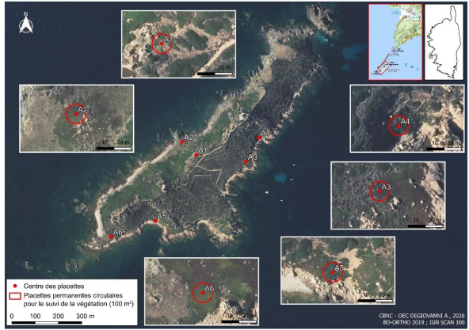

Figure 7: CBNC permanent vegetation-monitoring plots (A1–A6, 100 m²) on Mezu Mare / Grande Sanguinaire, off Ajaccio — the georeferenced ground-truth network over the same headland as the model run below. Source: CBNC – OEC (DEGIOVANNI A., 2026); base imagery BD ORTHO 2019 / IGN SCAN 100.

#### The model, run at the plots

To line the model up against this ground-truth network, we downloaded a fresh **250 m BD ORTHO tile (0.2 m, 4-band RGB+NIR, flown 10 July 2024)** centred on plots **A1 and A2** and ran the Dangermond model on it. The model flags iceplant across much of the headland, and **both A1 and A2 fall inside (or right beside) predicted patches** — the first direct, if still un-checked, overlap between model output and the CBNC plot network.

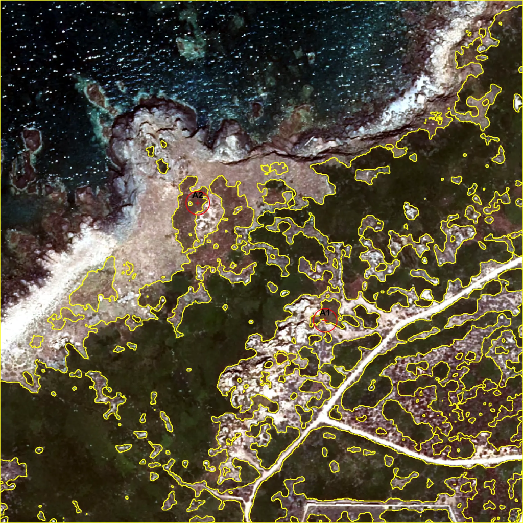

Figure 8: Dangermond model on the Mezu Mare BD ORTHO 2024 tile (10 July 2024), with CBNC plots **A1** and **A2** marked (red). Yellow = predicted iceplant. Both plots sit within predicted stands — exactly the points where CBNC ground data could confirm or refute the model.

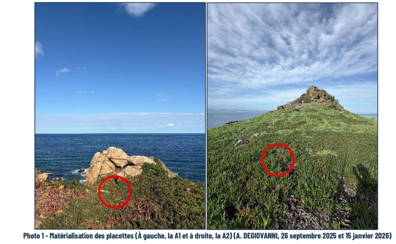

Figure 9: The plots on the ground — CBNC “matérialisation des placettes”: A1 (left) and A2 (right), plot markers among the coastal vegetation. Source: CBNC – OEC (A. DEGIOVANNI, 26 September 2025 & 15 January 2026).

**Caveat — not every green mat is iceplant.** On Mezu Mare a lot of the coastal ground *is* iceplant, but not all of it: maquis, grasses and other coastal vegetation grow interleaved with it. Some of the model’s polygons will be these look-alikes rather than *Carpobrotus* — which is precisely why georeferenced ground plots (and knowing what else grows here) are needed to separate true detections from false positives.

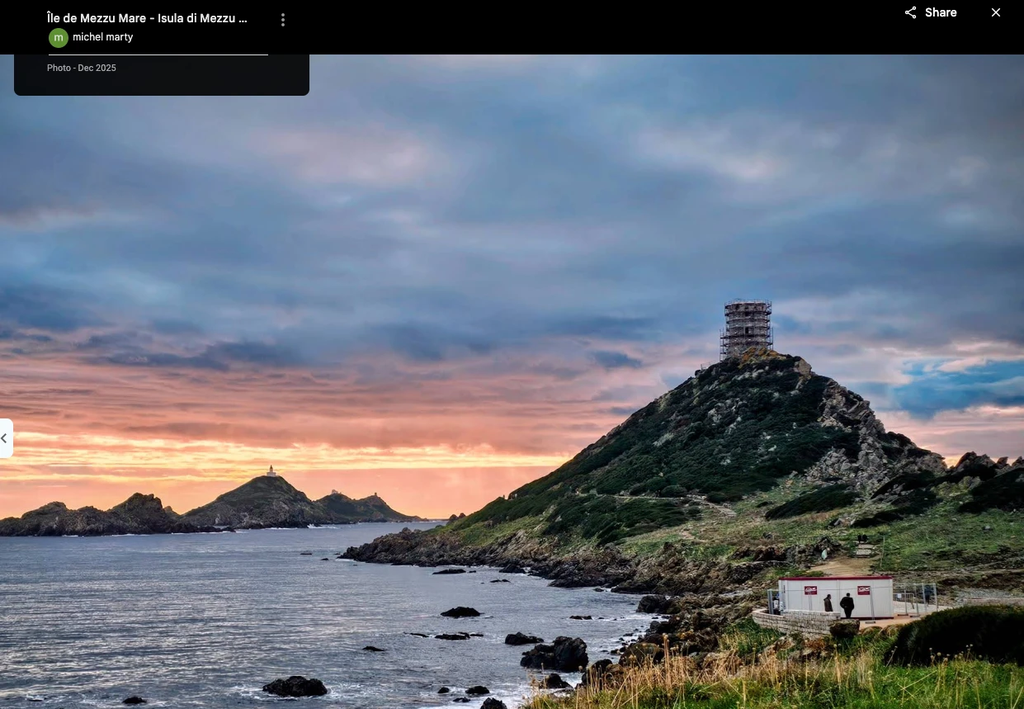

Figure 10: Mezu Mare coastal vegetation — iceplant mats mixed with other, non-iceplant coastal vegetation, a reminder that not all green here is *Carpobrotus*. Source: Google Maps (michel marty, Dec 2025).

## Validation sources

Nothing here is validated yet. Candidate sources of ground truth for Corsica, roughly in order of how directly usable they are:

- **Google Street View** — ground-level confirmation at points the model flags, as in the two views above. Cheap first-pass check; coverage is road-biased and dated, so it confirms presence better than absence.
- **GBIF occurrence records** — *Carpobrotus* points already pulled for Corsica in the main pipeline; useful as presence anchors, but they are opportunistic points, not delineated extent. The error or uncertainty in coordinates can also be problematic.
- **Local eradication organisations’ removal records** — groups actively pulling iceplant (below) know exactly where dense stands are, and where they *were* before removal. These are the most valuable potential validation data: georeferenced, expert-confirmed infestations, and — because removal happens over several years — a built-in test of whether the model can track change.
- **Prior aerial / remote-sensing detection studies** — some Mediterranean iceplant mapping work exists and could provide comparison extents.

## Eradication efforts & local organisations

Active Corsica iceplant-removal programmes. Beyond context, each is a possible validation partner (see above) — they hold on-the-ground knowledge of exact infestation locations.

- **Grand Site de la Parata (Ajaccio)** — a mixed syndicate of the City of Ajaccio and the South Corsica Department is running a multi-year campaign against *griffes de sorcière* at the Grand Site de la Parata (Sanguinaires). On 3 March 2023 roughly 30 volunteers cleared over 1,000 m² of the species, with about 200 schoolchildren joining follow-up work; the effort is planned over five years to suppress regrowth and restore native biodiversity. [Article](https://www.corsenetinfos.corsica/Ajaccio-le-Grand-site-de-la-Parata-declare-la-guerre-aux-griffes-de-sorciere_a69901.html)
- **I Sbuleca Mare (Lumiu, Balagne)** — a Corsican environmental group focused on coastal and marine biodiversity education, running *Carpobrotus* removal campaigns across Balagne coastal sites including Revellata, Punta Spanu, and **Ile-Rousse** (the site mapped above), alongside broader awareness work. [Sensibilisation page](https://isbulecamare.org/sensibilisation/) · [Video: I Sbuleca Mare tackling *griffes de sorcière* at Ile Rousse](https://www.youtube.com/watch?v=my0ey06khOY)

## Questions and Next steps

- **Reach out to the people running the existing monitoring / eradication efforts?** (CBNC / OEC, I Sbuleca Mare, Grand Site de la Parata.) Direct contact is likely the fastest route.
- **Access is hard right now** — the public data portal was hit by a cyber-attack last year and looks difficult to access, so a data request by email may be the only practical path.
- **Just ask for the data — but on what terms?** They may want **co-authorship** in exchange; worth deciding our position before reaching out.
- **Image pre-processing** - not sure what is needed?
- **Image sources** - start with the aerial first and then other imagery?
- **Validate the outputs** against ground data — start with the CBNC Mezu Mare plots and the eradication organisations’ known stands (Parata, Ile Rousse) and Street-View spot-checks; then quantify (precision / recall, area agreement) rather than eyeballing.
- **Time of year & across years** — compare model output across BD ORTHO editions (different years) and, where available, different acquisition seasons: test whether it can track spread and, at eradication sites (Mezu Mare 2025 → 2026+), measure removal / regrowth over time, and check how sensitive detection is to the season the imagery was flown (iceplant colours up seasonally).
- **More sites & conditions** — extend beyond these two headlands to a range of Corsica coastal settings (dune, cliff, urban edge) to see where transfer holds and where it breaks.
- **Thresholding & post-processing** — tune the detection threshold and clean up speckle; decide on a minimum mapping unit.
- **Quantify simple vs. full model** — turn the visual comparison above into numbers on a labelled test set.
- **NIR / band sensitivity** — check how much the near-infrared band contributes to transfer, and whether an RGB-only fallback is viable where NIR is missing.